# Cantilever beam: single beam inference, non-isotropic error

Olga Egorova

26 April 2021

We consider here a toy example of a 3-layer beam with 2 interfaces, clamped at one end, with no extra load – just gravity.

The following code specifies the virtual environment where the computer model (pyComp) lives, and the paths to the python scripts producing outputs for (1) generating “artificial” data (e.g. using finer grid) and (2) simulations. The paths need to be changed(!)

If no python code is to be run, please ignore this chuck of code.

First we set up the parameters – the number of beams that we have “observed” (here – it is $1$), number of data points observed and the number of simulations.

```r
n_beam = 1           # number of "true" underlying theta-s
n_data = 10          # number of data points
n_simulations = 30   # number of simulations
```

1. Data

Picking the “true” theta-s (choosing at random in the region $[-\pi/30, \pi/30]$), running the FE model and saving the displacements. If no python code is run – please go straight to the next chunk.

```r
# Choosing the true theta within the region of -/+(pi/30)
theta_data = data.table(matrix(runif(n = 3*n_beam, min = -pi/30, max = pi/30), nrow = n_beam))
colnames(theta_data) = c("theta_1", "theta_2", "theta_3")
theta_data
```

| theta_1 | theta_2 | theta_3 |
| --- | --- | --- |
| -0.07371136 | 0.02090705 | 0.02113138 |

```r
############################################
# Load the FE model for data generation
############################################
source_python(python_data)
dt_coords = read.table("out/obs_coords.csv", header = FALSE, sep = ",",  col.names = c("x", "y", "z"))

# Obtain displacements across all observational points
dt_displacements = cbind(dt_coords, data.frame("D" = rep(0, nrow(dt_coords))))
for (d in 1:n_beam){
 dt_displacements[, ncol(dt_coords)+d] =
   myModel$solve(baseAngles + as.numeric(theta_data[d,]), TRUE, iterativeSolver = FALSE)
}
```

Data generation.

Given the “true” $\theta$-s and the displacement values, we assume normal independent measurement errors with zero mean and variance $\sigma^2_e$ (set up in the following chunk of code). The variance is constant across the observational points – it is attributed to the variability occurring from the observational process rather than from the location of the points or any other properties.

```r
theta_data = read.table("out/theta_data.csv", header = TRUE, sep = ",")
dt_data_coords = read.table("out/obs_coords.csv", header = FALSE, sep = ",",
                            col.names = c("x", "y", "z"))
dt_displacements = read.table("out/dt_displacements.csv", header = TRUE, sep = ",")
n_beam = nrow(theta_data)

## Get rid of "0" displacement values
inf_idx = which(abs(dt_displacements$D) < 1e-7)
dt_displacements = dt_displacements[-inf_idx,]
dt_data_coords = dt_data_coords[-inf_idx,]
dt_displacements$logD = log(-dt_displacements$D)
```

```
NaNs produced
```

```r
## Get rid of NAs
complete_idx = complete.cases(dt_displacements)
dt_displacements = dt_displacements[complete_idx,]
dt_data_coords = dt_data_coords[complete_idx,]

# Generate artificial data: additive iid errors
sigma_e = 10^(-8) ; sigma2_e = sigma_e^2  # constant measurement error variance for data generation
dt_displacements$data = dt_displacements$logD + rnorm(nrow(dt_displacements), mean = 0, sd = sigma_e)
dt_displacements
```

|  | x | y | z | D | logD | data |
| --- | --- | --- | --- | --- | --- | --- |
| 4 | 0.3020134 | 0.0000000 | 0.64 | -0.0001037748 | -9.173288e+00 | -9.173288e+00 |
| 5 | 0.4026846 | 0.0000000 | 0.64 | -0.0011692475 | -6.751395e+00 | -6.751395e+00 |
| 6 | 0.5033557 | 0.0000000 | 0.64 | -0.0027799224 | -5.885332e+00 | -5.885332e+00 |
| 7 | 0.6040268 | 0.0000000 | 0.64 | -0.0049090798 | -5.316669e+00 | -5.316669e+00 |
| 8 | 0.7046980 | 0.0000000 | 0.64 | -0.0075411110 | -4.887386e+00 | -4.887386e+00 |
| 9 | 0.8053691 | 0.0000000 | 0.64 | -0.0106659485 | -4.540699e+00 | -4.540699e+00 |
| 10 | 0.9060403 | 0.0000000 | 0.64 | -0.0142760421 | -4.249173e+00 | -4.249173e+00 |
| 11 | 1.0067114 | 0.0000000 | 0.64 | -0.0183648584 | -3.997316e+00 | -3.997316e+00 |
| 12 | 1.1073826 | 0.0000000 | 0.64 | -0.0229262378 | -3.775473e+00 | -3.775473e+00 |
| 13 | 1.2080537 | 0.0000000 | 0.64 | -0.0279541097 | -3.577191e+00 | -3.577191e+00 |

[output cut: 990 more lines]

|  | x | y | z | data |
| --- | --- | --- | --- | --- |
| 18 | 1.7114094 | 0.0000000 | 0.64 | -2.81553301 |
| 43 | 4.2281879 | 0.0000000 | 0.64 | -1.01212533 |
| 140 | 13.9932886 | 0.0000000 | 0.64 | 0.96467018 |
| 524 | 7.3489933 | 0.3157895 | 0.64 | -0.02269975 |
| 2252 | 0.1006711 | 1.5789474 | 0.64 | -6.86546748 |
| 2491 | 9.0604027 | 1.6842105 | 0.64 | 0.32745184 |

2. Simulations

Running the simulations: choosing $\theta$-s as a space-filling design ($\mbox{mogp_emulator\$LatinHypercubeDesign}$ function iin Python) from a “feasible” region: $\pm \pi/30$.

$\mbox{theta_simulation}$ contains the values of $\theta$-s used for simulations, corresponding to each column of the simulation outputs $\mbox{dt_all_simulation}$.

If no Python code is run – please go to the next chunk.

```r
#########################################
# Choose theta values for simulation
#########################################
mogp_emulator = import("mogp_emulator")
theta_interval = tuple(-pi/30, pi/30, convert = TRUE)
theta_design = mogp_emulator$LatinHypercubeDesign(list(theta_interval, theta_interval, theta_interval))
theta_simulation = theta_design$sample(n_simulations)
colnames(theta_simulation) = c("theta_1", "theta_2", "theta_3")

#########################################
# Load the FE model for simulations
#########################################
source_python(python_sim)
n_sim_coords = length(myModel$tmp)

dt_all_simulation = matrix(0, ncol = n_simulations, nrow = n_sim_coords)
# running the simulations
for (p in 1:n_simulations){
  dt_all_simulation[,p] = myModel$solve(baseAngles + theta_simulation[p,], TRUE, iterativeSolver = FALSE)
}

write.csv(theta_simulation, "out/theta_simulation.csv", row.names = FALSE)
write.csv(dt_all_simulation, "out/dt_all_simulation.csv", row.names = FALSE)
```

Read the simulation output for all the observational points and choose the ones to use in the modelling.

The final dataset $\mbox{dt_simulation}$ contains $n_simulation$ rows of location coordinates, $\theta$-s and simulation outputs.

| x | y | z | theta_1 | theta_2 | theta_3 | s |
| --- | --- | --- | --- | --- | --- | --- |
| 4.0540541 | 0.0000000 | 0.64 | -0.05502287 | 0.1039959916 | -0.09240256 | -0.9932128 |
| 9.9324324 | 0.2222222 | 0.64 | -0.03228576 | -0.0835955871 | 0.06217932 | 0.5139846 |
| 11.1486486 | 0.2222222 | 0.64 | -0.07130426 | -0.0445455831 | -0.03342942 | 0.7170340 |
| 3.2432432 | 0.6666667 | 0.64 | -0.09569777 | 0.0534876721 | -0.09853249 | -1.4031045 |
| 8.5135135 | 0.6666667 | 0.64 | 0.09544282 | -0.0605302470 | 0.09918610 | 0.3187131 |
| 0.2027027 | 0.8888889 | 0.64 | -0.04878801 | 0.0004994673 | 0.01207807 | -6.0272313 |

In case the previous chunk is not run – read the simulation inputs (location coordinates and $\theta$-s) and outputs.

```r
dt_simulation = read.table("out/dt_simulation.csv", header = TRUE, sep = ",")
XT_sim = dt_simulation[, 1:(ncol(dt_simulation) -1)]
dt_data = read.table("out/dt_data.csv", header = TRUE, sep = ",")

head(dt_simulation)
```

|  | x | y | z | theta_1 | theta_2 | theta_3 | s |
| --- | --- | --- | --- | --- | --- | --- | --- |
| 1 | 4.0540541 | 0.0000000 | 0.64 | -0.05502287 | 0.1039959916 | -0.09240256 | -0.9932128 |
| 2 | 9.9324324 | 0.2222222 | 0.64 | -0.03228576 | -0.0835955871 | 0.06217932 | 0.5139846 |
| 3 | 11.1486486 | 0.2222222 | 0.64 | -0.07130426 | -0.0445455831 | -0.03342942 | 0.7170340 |
| 4 | 3.2432432 | 0.6666667 | 0.64 | -0.09569777 | 0.0534876721 | -0.09853249 | -1.4031045 |
| 5 | 8.5135135 | 0.6666667 | 0.64 | 0.09544282 | -0.0605302470 | 0.09918610 | 0.3187131 |
| 6 | 0.2027027 | 0.8888889 | 0.64 | -0.04878801 | 0.0004994673 | 0.01207807 | -6.0272313 |

```r
head(XT_sim)
```

|  | x | y | z | theta_1 | theta_2 | theta_3 |
| --- | --- | --- | --- | --- | --- | --- |
| 1 | 4.0540541 | 0.0000000 | 0.64 | -0.05502287 | 0.1039959916 | -0.09240256 |
| 2 | 9.9324324 | 0.2222222 | 0.64 | -0.03228576 | -0.0835955871 | 0.06217932 |
| 3 | 11.1486486 | 0.2222222 | 0.64 | -0.07130426 | -0.0445455831 | -0.03342942 |
| 4 | 3.2432432 | 0.6666667 | 0.64 | -0.09569777 | 0.0534876721 | -0.09853249 |
| 5 | 8.5135135 | 0.6666667 | 0.64 | 0.09544282 | -0.0605302470 | 0.09918610 |
| 6 | 0.2027027 | 0.8888889 | 0.64 | -0.04878801 | 0.0004994673 | 0.01207807 |

```r
head(dt_data)
```

|  | x | y | z | data |
| --- | --- | --- | --- | --- |
| 1 | 1.7114094 | 0.0000000 | 0.64 | -2.81553301 |
| 2 | 4.2281879 | 0.0000000 | 0.64 | -1.01212533 |
| 3 | 13.9932886 | 0.0000000 | 0.64 | 0.96467018 |
| 4 | 7.3489933 | 0.3157895 | 0.64 | -0.02269975 |
| 5 | 0.1006711 | 1.5789474 | 0.64 | -6.86546748 |
| 6 | 9.0604027 | 1.6842105 | 0.64 | 0.32745184 |

The following sets up the rstan environment, and the parameters for the stan model

```r
## Set up the environment
## https://betanalpha.github.io/assets/case_studies/gaussian_processes.html#21_Simulating_From_A_Gaussian_Process

# set stan to execute multiple Markov chains in parallel
rstan_options(auto_write = TRUE)
options(mc.cores = parallel::detectCores())
parallel:::setDefaultClusterOptions(setup_strategy = "sequential")

util = new.env()
par(family="CMU Serif", las=1, bty="l", cex.axis=1, cex.lab=1, cex.main=1,
    xaxs="i", yaxs="i", mar = c(5, 5, 3, 5))

## https://github.com/adChong/bc-stan/blob/master/src/main.R

# get dimensions of dataset
p = ncol(dt_data_coords)     # number of input factors
q = ncol(XT_sim) - p    # number of calibration parameters
n = nrow(dt_data)       # sample size of observed field data
m = nrow(XT_sim)        # sample size of computer simulation data

# extract data from DATAFIELD (Table 3) and DATACOMP (Table 4)
y = dt_data[,p+1]                   # observed output
eta = dt_simulation[,p+q+1]         # simulation output
xf = dt_data[,1:p]                  # observed input
xc = as.matrix(XT_sim[, 1:p])       # simulation input
tc = as.matrix(XT_sim[,(p+1):(p+q)])       # calibration parameters input

x_pred = xf                     # design points for predictions
n_pred = nrow(x_pred)           # number of predictions

# standardisation of output y and eta w.r.t eta
eta_mu = mean(eta, na.rm = TRUE) # mean value
eta_sd = sd(eta, na.rm = TRUE)   # standard deviation
eta = (eta - eta_mu) / eta_sd

y_mu = mean(y, na.rm = TRUE) # mean value
y_sd = sd(y, na.rm = TRUE)   # standard deviation
y = (y - eta_mu) / eta_sd

# Put design points xf and xc on [0,1]
x = rbind(as.matrix(xf), as.matrix(xc))
for (i in (1:ncol(x))){
  x_min = min(x[,i], na.rm = TRUE)
  x_max = max(x[,i], na.rm = TRUE)
  xf[,i] = (xf[,i] - x_min) / (x_max - x_min)
  xc[,i] = (xc[,i] - x_min) / (x_max - x_min)
  x_pred[,i] = (x_pred[,i] - x_min) / (x_max - x_min)
}

# Put calibration parameters t on domain [0,1]
for (j in (1:ncol(tc))){
  tc_min = min(tc[,j], na.rm = TRUE)
  tc_max = max(tc[,j], na.rm = TRUE)
  tc[,j] = (tc[,j] - tc_min) / (tc_max - tc_min)
}

# create data as list for input to Stan
stan_data = list(n=n, m=m, n_pred=n_pred, p=p, y=y, q=q, eta=eta,
                  xf=as.matrix(xf), xc=as.matrix(xc),
                  x_pred=as.matrix(x_pred), tc=as.matrix(tc))
```

Fit a calibration model with the discrepancy term $: $y(x) = \eta(x,t) + \delta(x) + \varepsilon$.

The covariance function for the GP approximating $\delta(x)$ is
$$\mbox{Cov}(\mathbf{x}^{(i)}, \mathbf{x}^{(j)}) = \frac{1}{\lambda_\delta}\left[\mbox{exp}\left(-\frac{1}{2}\left[\frac{d_{x_i, x_j}^2}{\phi_x} + \frac{d_{y_i, y_j}^2}{\phi_y} + \frac{d_{z_i, z_j}^2}{\phi_z}\right]\right) + \delta_{ij}\tau^2_{\delta} x_i^2 \right]$$

Fitting can take a couple of minutes – that does depend on the number of data and simulation points.

```r
# run model in stan
fit = stan(file = "Non_iso_delta_kernel.stan",
           data = stan_data,
           iter = 4000,
           chains = 3)
```

```
hash mismatch so recompiling; make sure Stan code ends with a blank line
```

```
starting worker pid=55072 on localhost:11235 at 16:22:26.233
starting worker pid=55088 on localhost:11235 at 16:22:26.630
starting worker pid=55102 on localhost:11235 at 16:22:26.951
```

[output not shown]

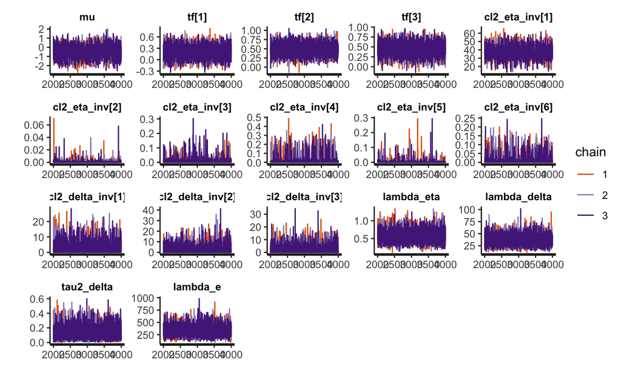

```r
# plot traceplots, excluding warm-up
stan_trace(fit, pars = c("mu", "tf", "cl2_eta_inv", "cl2_delta_inv",
                         "lambda_eta", "lambda_delta", "tau2_delta", "lambda_e"))  #"mu",
```

```r
# summarize results
print(fit, pars = c("mu", "tf", "cl2_eta_inv", "cl2_delta_inv",
                    "lambda_eta", "lambda_delta", "tau2_delta", "lambda_e"))
```

```
Inference for Stan model: Non_iso_delta_kernel.
3 chains, each with iter=4000; warmup=2000; thin=1;
post-warmup draws per chain=2000, total post-warmup draws=6000.

                   mean se_mean     sd   2.5%    25%    50%    75%  97.5% n_eff Rhat
mu                -0.48    0.01   0.63  -1.73  -0.89  -0.48  -0.06   0.75  2256 1.00
tf[1]              0.21    0.00   0.16  -0.11   0.10   0.21   0.31   0.52  2181 1.00
tf[2]              0.48    0.00   0.15   0.18   0.38   0.48   0.58   0.78  5823 1.00
tf[3]              0.43    0.00   0.16   0.11   0.33   0.44   0.54   0.74  3897 1.00
cl2_eta_inv[1]    36.49    0.19   7.04  21.53  32.10  36.05  40.83  51.18  1384 1.00
cl2_eta_inv[2]     0.00    0.00   0.00   0.00   0.00   0.00   0.00   0.00  4740 1.00
cl2_eta_inv[3]     0.01    0.00   0.02   0.00   0.00   0.00   0.01   0.06  1052 1.00
cl2_eta_inv[4]     0.03    0.00   0.05   0.00   0.00   0.01   0.02   0.19   412 1.01
cl2_eta_inv[5]     0.00    0.00   0.01   0.00   0.00   0.00   0.00   0.02  4355 1.00
cl2_eta_inv[6]     0.01    0.00   0.02   0.00   0.00   0.00   0.01   0.08  1556 1.00
cl2_delta_inv[1]   2.26    0.05   3.39   0.00   0.11   0.83   3.02  12.51  5538 1.00
cl2_delta_inv[2]   1.95    0.05   3.56   0.00   0.02   0.24   2.47  11.91  4380 1.00
cl2_delta_inv[3]   1.62    0.03   2.83   0.00   0.04   0.41   1.93  10.21  7086 1.00
lambda_eta         0.55    0.00   0.17   0.27   0.43   0.54   0.66   0.93  3700 1.00
lambda_delta      36.48    0.15  10.65  19.09  28.95  35.34  42.77  60.42  5383 1.00
tau2_delta         0.13    0.00   0.09   0.02   0.06   0.11   0.18   0.35  6180 1.00
lambda_e         324.37    1.47 103.02 160.50 249.40 311.82 386.14 557.74  4906 1.00

Samples were drawn using NUTS(diag_e) at Fri Apr 23 16:24:16 2021.
For each parameter, n_eff is a crude measure of effective sample size,
and Rhat is the potential scale reduction factor on split chains (at
convergence, Rhat=1).
```

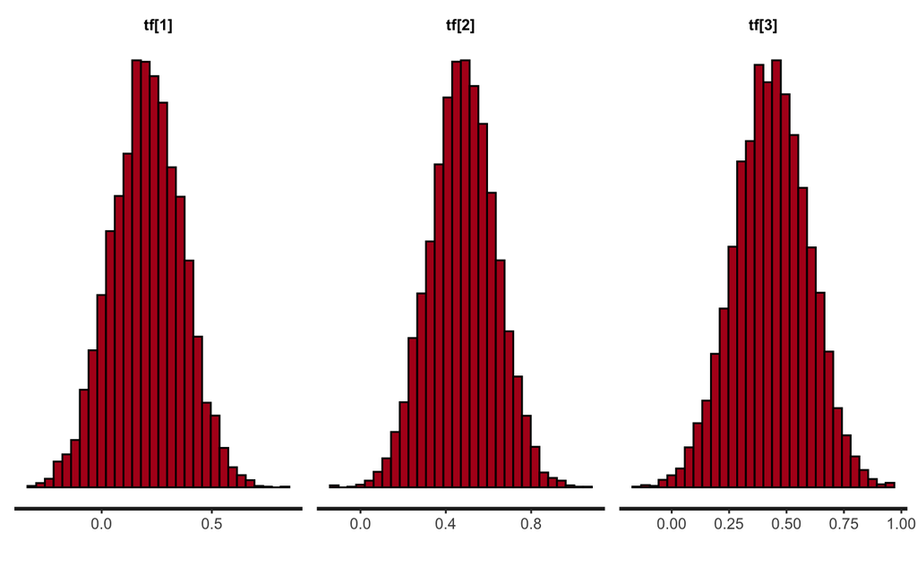

```r
# posterior probability distribution of tf
stan_hist(fit, pars = c("tf"))
```

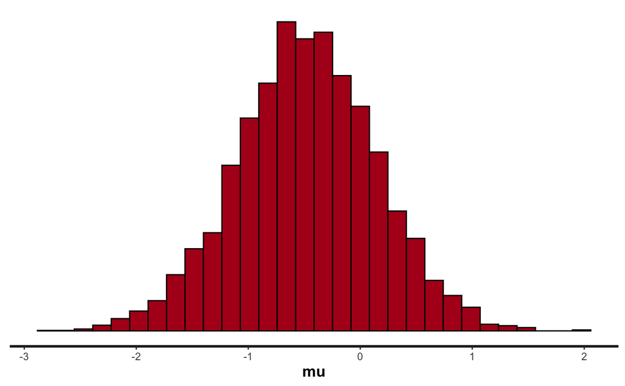

```r
stan_hist(fit, pars = c("mu"))
```

```r
# True scaled theta-s
c((theta_data[1,1]- min(XT_sim[,p+1]))/(max(XT_sim[,p+1]) - min(XT_sim[,p+1])),
  (theta_data[1,2]- min(XT_sim[,p+2]))/(max(XT_sim[,p+2]) - min(XT_sim[,p+2])),
  (theta_data[1,3]- min(XT_sim[,p+3]))/(max(XT_sim[,p+3]) - min(XT_sim[,p+3])))
```

```
[1] 0.1336852 0.5963423 0.6052232
```

```r
theta_data/(pi/180)
```

| theta_1 | theta_2 | theta_3 |
| --- | --- | --- |
| -4.22335 | 1.197886 | 1.210739 |

Look at pairs and triplets of theta posteriors – in contrast with marginals observed on the histograms before.

```r
df_of_draws = as.data.table(fit)
setnames(df_of_draws, old = c("tf[1]", "tf[2]", "tf[3]"),
         new = c("tf1", "tf2", "tf3"))
head(df_of_draws)
```

| mu | tf1 | tf2 | tf3 | rho_eta[1] | rho_eta[2] | rho_eta[3] | rho_eta[4] | rho_eta[5] | rho_eta[6] | rho_delta[1] | rho_delta[2] | rho_delta[3] | lambda_eta | lambda_delta | tau2_delta | lambda_e | cl2_eta_inv[1] | cl2_eta_inv[2] | cl2_eta_inv[3] | cl2_eta_inv[4] | cl2_eta_inv[5] | cl2_eta_inv[6] | cl2_delta_inv[1] | cl2_delta_inv[2] | cl2_delta_inv[3] | lp__ |
| --- | --- | --- | --- | --- | --- | --- | --- | --- | --- | --- | --- | --- | --- | --- | --- | --- | --- | --- | --- | --- | --- | --- | --- | --- | --- | --- |
| -1.67024217 | 0.32256185 | 0.5034226 | 0.3294989 | 4.881356e-05 | 0.9999994 | 0.9992007 | 0.9990222 | 0.9999697 | 0.9998052 | 0.91229428 | 0.6194455 | 0.9880711 | 0.3605004 | 26.88414 | 0.44646651 | 456.1240 | 39.71001 | 2.497003e-06 | 0.003198540 | 0.003913071 | 1.212741e-04 | 0.0007793100 | 0.3671707 | 1.915722e+00 | 0.04800259 | 91.87517 |
| -0.65876932 | 0.13258958 | 0.3187585 | 0.6232279 | 2.783203e-04 | 0.9996396 | 0.9986021 | 0.9995336 | 0.9999951 | 0.9992116 | 0.36427794 | 0.9884055 | 0.3358178 | 0.6743654 | 34.39484 | 0.02964724 | 261.6481 | 32.74695 | 1.441998e-03 | 0.005595487 | 0.001866171 | 1.971100e-05 | 0.0031547788 | 4.0393525 | 4.664906e-02 | 4.36474620 | 94.15793 |
| -1.18615984 | 0.26018111 | 0.4553168 | 0.5114916 | 2.504313e-04 | 0.9999909 | 0.9964563 | 0.9905243 | 0.9994345 | 0.9997674 | 0.42678726 | 0.9649970 | 0.4138210 | 0.7697233 | 29.67254 | 0.04345151 | 321.1024 | 33.16930 | 3.627823e-05 | 0.014199897 | 0.038083671 | 2.262577e-03 | 0.0009303869 | 3.4058785 | 1.425210e-01 | 3.52928731 | 94.71209 |
| -0.05353536 | 0.37836923 | 0.4501427 | 0.4690565 | 1.174550e-04 | 0.9999743 | 0.9996549 | 0.9995773 | 0.9999998 | 0.9995319 | 0.51402859 | 0.9911401 | 0.9937712 | 0.3966897 | 37.13640 | 0.26539473 | 473.0604 | 36.19782 | 1.028004e-04 | 0.001380546 | 0.001691177 | 6.009825e-07 | 0.0018727064 | 2.6619056 | 3.559760e-02 | 0.02499305 | 96.20546 |
| -0.17304540 | 0.40949297 | 0.6103175 | 0.5033315 | 5.259512e-04 | 0.9998944 | 0.9970204 | 0.9988363 | 0.9999991 | 0.9997284 | 0.08637418 | 0.2793245 | 0.9787688 | 0.4201831 | 16.45239 | 0.18259096 | 427.5362 | 30.20121 | 4.224022e-04 | 0.011936042 | 0.004657328 | 3.529334e-06 | 0.0010866541 | 9.7962661 | 5.101524e+00 | 0.08583934 | 90.49699 |
| -0.89787810 | 0.03077811 | 0.5837175 | 0.3914669 | 3.991252e-04 | 1.0000000 | 0.9988168 | 0.9994797 | 0.9997668 | 0.9996124 | 0.94476638 | 1.0000000 | 0.3620394 | 0.2497899 | 50.30069 | 0.11208616 | 285.6538 | 31.30494 | 3.279103e-08 | 0.004735687 | 0.002081588 | 9.329297e-04 | 0.0015507409 | 0.2272704 | 1.599893e-09 | 4.06400875 | 87.79642 |

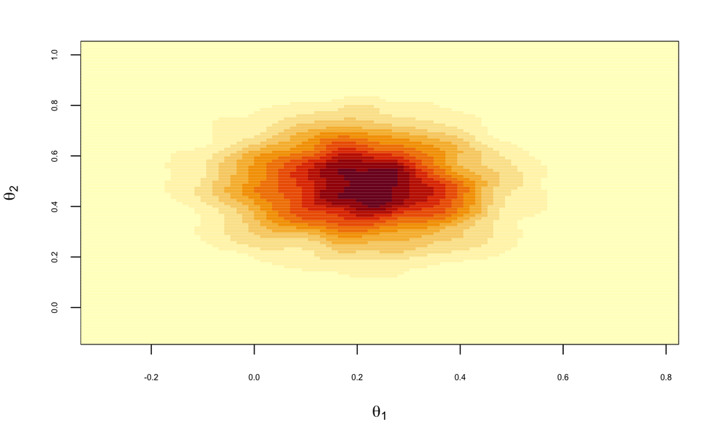

```r
library(MASS)

# par()    #change plotting parameters
par(cex.axis = 0.5)
k1 <- kde2d(df_of_draws$tf1, df_of_draws$tf2, n=100)
image(k1, xlab = expression(theta[1]), ylab = expression(theta[2]))
```

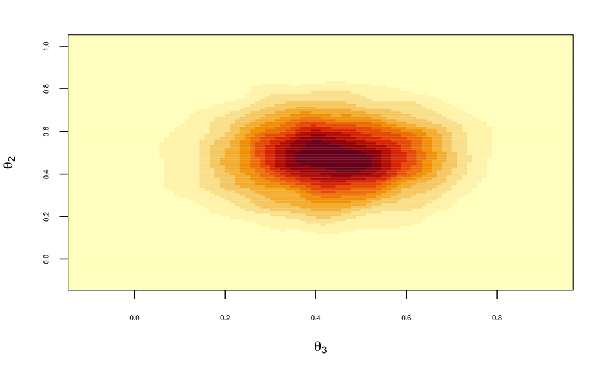

```r
# Adjust binning (interpolate - can be computationally intensive for large datasets)
k2 <- kde2d(df_of_draws$tf3, df_of_draws$tf2, n=100)
image(k2, xlab = expression(theta[3]), ylab = expression(theta[2]))
```

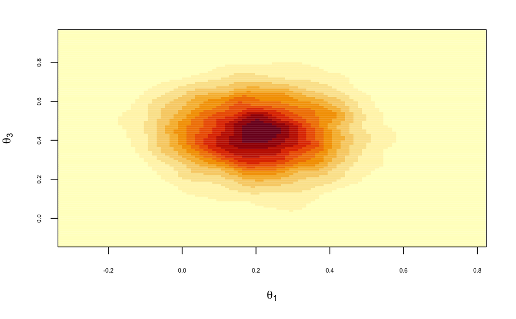

```r
k3 <- kde2d(df_of_draws$tf1, df_of_draws$tf3, n=100)
image(k3, xlab = expression(theta[1]), ylab = expression(theta[3]))
```

Another model: with the non-isotropic part in the kernel for $\eta$ as well, not just the discrepancy term $\delta$. The number of correlation parameters is reduced: leave one for locations and one for $\theta-$s.

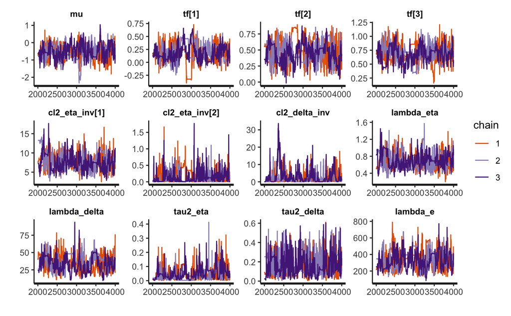

```r
stan_trace(fit1, pars = c("mu", "tf", "cl2_eta_inv", "cl2_delta_inv",
                         "lambda_eta", "lambda_delta", "tau2_eta","tau2_delta", "lambda_e"))  #"mu",

# summarize results
print(fit1, pars = c("mu", "tf", "cl2_eta_inv", "cl2_delta_inv",
                    "lambda_eta", "lambda_delta", "tau2_eta", "tau2_delta", "lambda_e"))
```

```
Inference for Stan model: Non_iso_eta_delta.
3 chains, each with iter=4000; warmup=2000; thin=1;
post-warmup draws per chain=2000, total post-warmup draws=6000.

                 mean se_mean     sd   2.5%    25%    50%    75%  97.5% n_eff Rhat
mu              -0.53    0.04   0.39  -1.31  -0.77  -0.53  -0.27   0.17   105 1.02
tf[1]            0.18    0.02   0.16  -0.15   0.09   0.17   0.28   0.48    76 1.01
tf[2]            0.48    0.02   0.16   0.18   0.37   0.48   0.58   0.81    75 1.03
tf[3]            0.69    0.02   0.15   0.37   0.60   0.69   0.78   0.98    80 1.02
cl2_eta_inv[1]   7.88    0.21   2.04   4.39   6.37   7.62   9.19  12.86    92 1.02
cl2_eta_inv[2]   0.11    0.02   0.15   0.00   0.01   0.05   0.14   0.50    75 1.06
cl2_delta_inv    1.94    0.37   3.37   0.00   0.09   0.59   2.27  11.45    81 1.05
lambda_eta       0.69    0.02   0.17   0.41   0.56   0.68   0.81   1.05   108 1.02
lambda_delta    34.02    1.10  10.41  16.12  26.15  33.60  41.02  54.72    90 1.02
tau2_eta         0.04    0.01   0.04   0.00   0.01   0.03   0.06   0.14    50 1.08
tau2_delta       0.16    0.01   0.10   0.02   0.08   0.14   0.23   0.37   144 1.01
lambda_e       331.89   10.59 105.97 166.30 246.62 325.55 400.43 563.52   100 1.01

Samples were drawn using NUTS(diag_e) at Fri Apr 23 16:47:28 2021.
For each parameter, n_eff is a crude measure of effective sample size,
and Rhat is the potential scale reduction factor on split chains (at
convergence, Rhat=1).
```

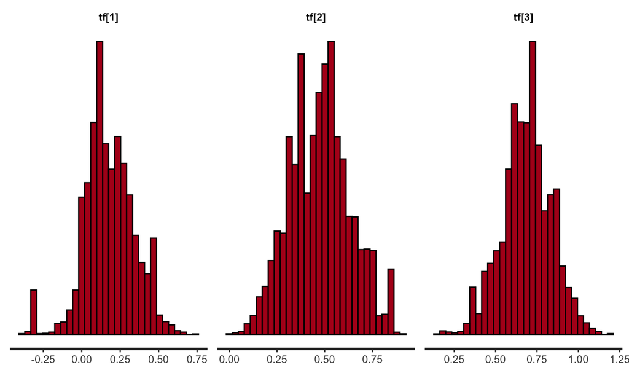

```r
# posterior probability distribution of tf
stan_hist(fit1, pars = c("tf"))
```

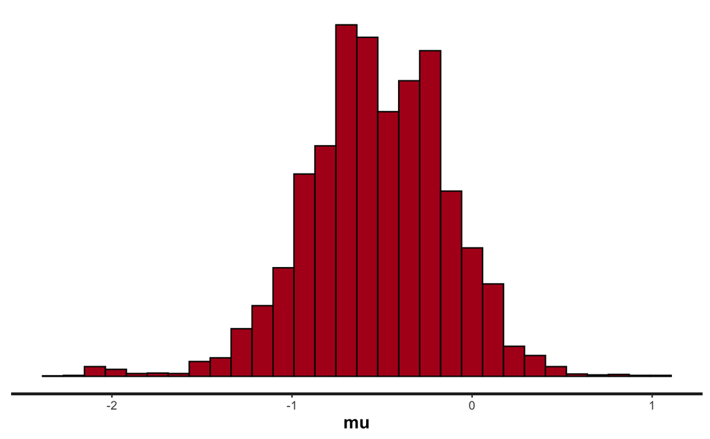

```r
stan_hist(fit1, pars = c("mu"))
```

Look at pairs and triplets of theta posteriors.

```r
df_of_draws1 = as.data.table(fit1)
setnames(df_of_draws1, old = c("tf[1]", "tf[2]", "tf[3]"),
         new = c("tf1", "tf2", "tf3"))
head(df_of_draws1)
```

| mu | tf1 | tf2 | tf3 | rho_eta[1] | rho_eta[2] | rho_delta | lambda_eta | lambda_delta | tau2_delta | tau2_eta | lambda_e | cl2_eta_inv[1] | cl2_eta_inv[2] | cl2_delta_inv | lp__ |
| --- | --- | --- | --- | --- | --- | --- | --- | --- | --- | --- | --- | --- | --- | --- | --- |
| -0.7522615 | 0.1660652 | 0.5467516 | 0.6856757 | 0.1527443 | 0.9998437 | 0.9868162 | 0.5189292 | 39.48662 | 0.08948228 | 0.008466152 | 217.9474 | 7.515961 | 0.0006252142 | 0.05308592 | 43.69397 |
| -0.7376834 | 0.1641929 | 0.5517371 | 0.6895018 | 0.1482259 | 0.9998315 | 0.9884780 | 0.5134637 | 40.02243 | 0.09041442 | 0.008206534 | 220.5596 | 7.636072 | 0.0006739820 | 0.04635559 | 43.78351 |
| -0.7294170 | 0.1696669 | 0.5614592 | 0.6870828 | 0.1444905 | 0.9998070 | 0.9875499 | 0.5159057 | 41.15325 | 0.09073477 | 0.008166042 | 217.4007 | 7.738166 | 0.0007720748 | 0.05011308 | 43.64032 |
| -0.7313047 | 0.1724614 | 0.5628323 | 0.6794276 | 0.1456548 | 0.9997820 | 0.9942093 | 0.5093351 | 41.60564 | 0.09103857 | 0.008684276 | 220.3727 | 7.706063 | 0.0008719165 | 0.02323014 | 44.27088 |
| -0.7323301 | 0.1765390 | 0.5574876 | 0.6841290 | 0.1466517 | 0.9997982 | 0.9915478 | 0.5047796 | 41.10086 | 0.08904747 | 0.008681468 | 218.5253 | 7.678780 | 0.0008070881 | 0.03395255 | 43.95718 |
| -0.7360425 | 0.1755824 | 0.5553180 | 0.6865517 | 0.1469466 | 0.9997951 | 0.9944241 | 0.5059640 | 41.01921 | 0.09015650 | 0.008518584 | 220.6911 | 7.670743 | 0.0008196802 | 0.02236587 | 44.31194 |

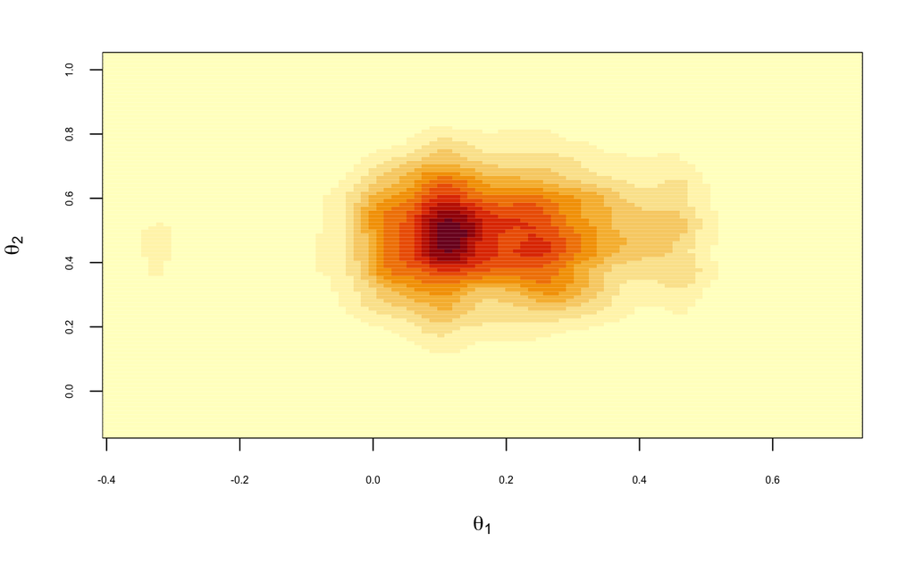

```r
library(MASS)

par(cex.axis = 0.5)
k1 <- kde2d(df_of_draws1$tf1, df_of_draws$tf2, n=100)
image(k1, xlab = expression(theta[1]), ylab = expression(theta[2]))
```

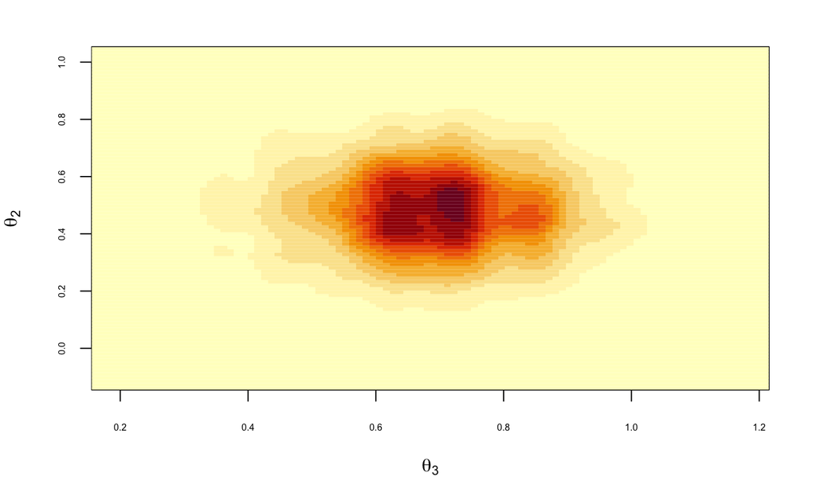

```r
# Adjust binning (interpolate - can be computationally intensive for large datasets)
k2 <- kde2d(df_of_draws1$tf3, df_of_draws$tf2, n=100)
image(k2, xlab = expression(theta[3]), ylab = expression(theta[2]))
```

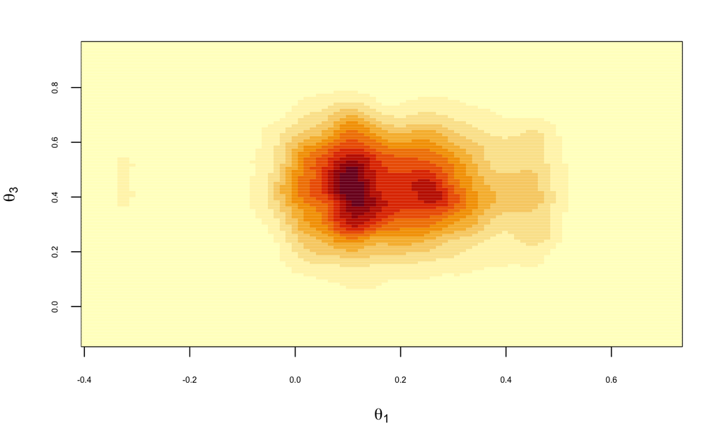

```r
k3 <- kde2d(df_of_draws1$tf1, df_of_draws$tf3, n=100)
image(k3, xlab = expression(theta[1]), ylab = expression(theta[3]))
```